# o-well

Hello

This is my notebook for the data we were given along with the data and code I used to read it in.

This data is looking at and describing the physical and chemical parameters of groundwater samples and the dissolved metals in the groundwater.

It is pretty obvious that the location of the wells depending on the type of landscape and the location of the fault has a direct impact on what is in the water in the well.

There is also a connection with the well and what is in the water.

Getting this program to fully work was a bit of a struggle. It took me quite a while to figure out how the data frames fully work but it was a nice challenge. Once I got the data read in I had a few issues with formatting but after messing around with it a bit I got it to be the format that I wanted it to be.

The second data set was kind of annoying to work with though since we had to work around the mean, median, etc, in between the wells so having to read in certain parts and connecting them seemed like more work than should’ve been needed.

This data is pretty important for the health of the people who are using this as drinking water. There are definately different precautions that need to be taken for each well to make it safe to drink so these data sets can help make it possible to drink the water.

```r
knitr::opts_chunk$set(echo = TRUE)
library(pdftools)
library(tidyverse)
```

```r
well_text <- pdf_text("/Users/traviscripe/Desktop/github/WSU_STATS419_2021/datasets/Well/Well-23.pdf") %>%
  readr::read_lines()
stats1 <- well_text[363:387]
stats2<- well_text[422:438]
stats3<- well_text[443:447]
stats4 <- well_text[452]

revised_stats1 <- stats1[3:25] %>%
  str_squish() %>%
  str_replace_all(",", "")
  check = strsplit(revised_stats1, split = " ")
revised_stats2 <- stats2[1:17] %>%
  str_squish() %>%
  str_replace_all(",", "")
  check2 = strsplit(revised_stats2, split = " ")
revised_stats3 <- stats3[1:5] %>%
  str_squish() %>%
  str_replace_all(",", "")
  check3 = strsplit(revised_stats3, split = " ")
revised_stats4 <- stats4[1] %>%
  str_squish() %>%
  str_replace_all(",", "")
  check4 = strsplit(revised_stats4, split = " ")

stats_df1 <- plyr::ldply(check)
stats_df2 <- plyr::ldply(check2)
stats_df3 <- plyr::ldply(check3)
stats_df4 <- plyr::ldply(check4)

#total[1] <- NULL
text_data <- read.table("/Users/traviscripe/Desktop/github/WSU_STATS419_2021/datasets/Well/wells-location.txt", sep = "|", header = TRUE, dec = ".")

df1 <- data.frame(stats_df1)
df1[1] <- NULL
text_data[1] <- NULL
colnames(df1) <- 1:15
row.names(df1) <- 1 : 23
df2 <- data.frame(stats_df2)
df3 <- data.frame(stats_df3)
df4 <- data.frame(stats_df4)
alm_total <- rbind(df2, df3)
total <- rbind(alm_total, df4)
total$text_data <- text_data
total[1] <- NULL
colnames(total) <- 1 : 20
row.names(total) <- 1 : 23

df1$text_data <- text_data

view(text_data)

#view(df1)
#view(total)

fault <- c(2500, 2000, 500, 5600, 1400, 7000, 0, 1300, 6000, 1300, 500, 1000, 15000, 3000, 3000, 500, 600, 10000, 3000, 1000, 3000, 9000, 500)

geology <- c("Sand, clay, gravel", "Granite", "Alkaline granite, syenite", "Alkaline granite, syenite", "Granite, Volcanic rock, breccia", "Volcanic rock, breccia", "Sand, clay, gravel", "Alkaline granite, syenite", "Sand, clay, gravel", "Volcanic rock, breccia", "Alkaline granite, syenite", "Granite", "Sand, clay, gravel", "Sand, clay, gravel", "Volcanic rock, breccia", "Alkaline granite, syenite", "Sand, clay, gravel", "Sand, clay, gravel", "Sand, clay, gravel", "Sand, clay, gravel", "Sand, clay, gravel", "Sand, clay, gravel", "Alkaline granite, syenite")

df1 <- data.frame(df1, fault, geology)
view(df1)
total <- data.frame(total, fault, geology)
view(total)

my.list <- list(df1, total)

saveRDS(my.list, file = "wells.rds")

total;
```

```
##     X1  X2    X3  X4 X5  X6   X7  X8   X9  X10 X11 X12 X13  X14 X15   X16  X17
## 1  7.5 377  1780 269 19  75  338 226  852  302  42 1.1 0.4  977 185  3320 1540
## 2  7.4 382  1456 259 20  68  257 183  710  312  41 1.0 0.1  925 150  2946 1490
## 3  7.4 378  1471 476 35  66  238 189  710  797  40 1.1 0.1 1460 155  2976 1505
## 4  7.5 382  1578 374 17  60  226 220  745  413  39 1.1 0.1 1180 180  3144 1566
## 5  7.7 376  1411 291  7  58  191 214  710  178  40 1.1 0.1  966 175  2906 1495
## 6  7.8 380  1400 464  3  58  338 159  710  935  40 1.0 0.1 1400 130  2880 1480
## 7  7.6 374  1683 369 17  83  272 128  781  606  42 1.0 0.1 1261 105  3198 1515
## 8  7.3 377  1184 330 10  42  132 128  568  341  42 1.0 0.1  998 105  2559 1375
## 9  7.5 370  1784 311 39  73  352 153  781  634   7 1.0 0.1 1078 125  3240 1456
## 10 7.4 367  1319 316  8  59  447 134  639  925  45 1.0 0.1 1033 110  2820 1501
## 11 7.6 367   985 234 10  35  112 165  497  120  40 1.0 0.1  729 135  2317 1332
## 12 7.6 386  1048 214  5  37  109 140  426  178  38 1.0 0.1  689 115  2488 1440
## 13 7.5 382  1878 399  6  72  267 165 1065  202  43 1.0 0.1 1293 135  3463 1585
## 14 7.4 380  3028 427 10 133  482 159 1562  298  48 1.0 0.1 1615 130  4758 1730
```

[output cut: 57 more lines]

```r
saveRDS(my.list, file = "saudi.txt")


hi <- unlist(my.list)
hi <- as.numeric(hi)
```

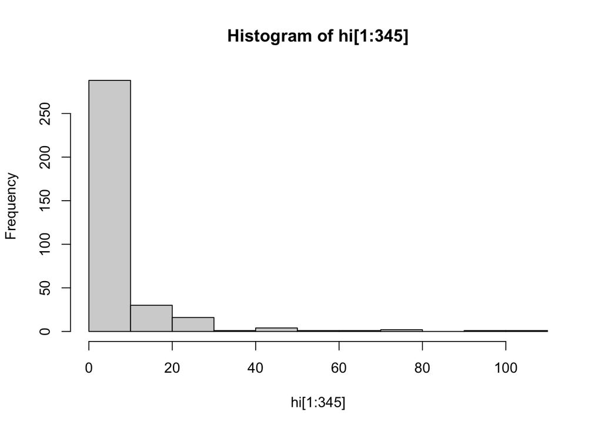

```r
hist(hi[1:345])
```

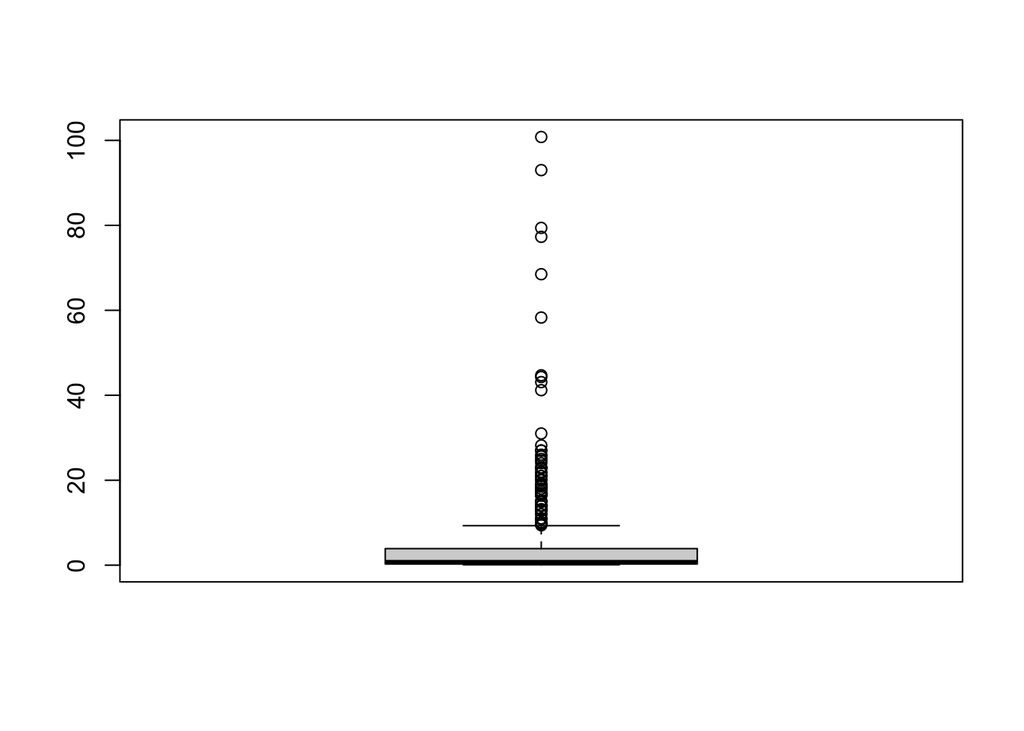

```r
boxplot(hi[1:345])
```

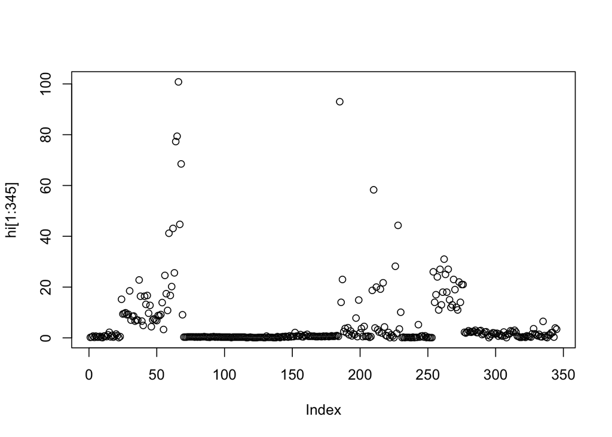

```r
plot(hi[1:345])
```

```r
print(hi[346:368])
```

```
##  [1] 28.63811 28.60347 28.57588 28.62036 28.56059 28.60279 28.48831 28.57232
##  [9] 28.43836 28.55365 28.65134 28.58444 28.51215 28.44827 28.62590 28.61294
## [17] 28.54015 29.24856 29.23533 29.29115 29.33692 29.31973 29.24509
```

```r
latitude <- hi[346:368]

print("plots of latitude")
```

```
## [1] "plots of latitude"
```

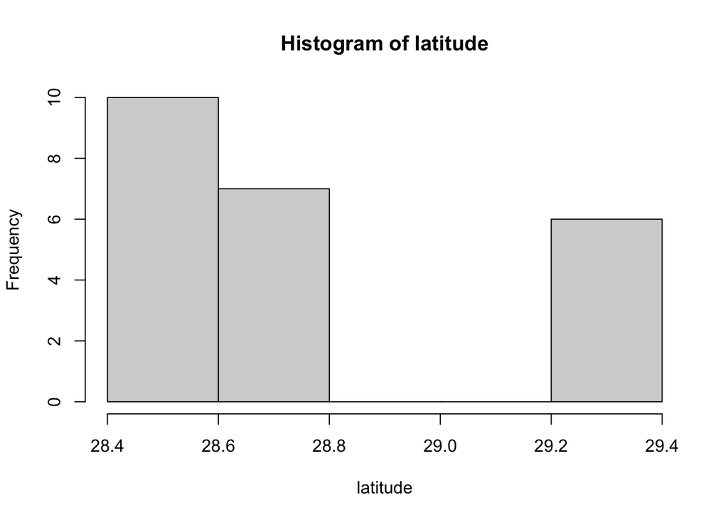

```r
hist(latitude)
```

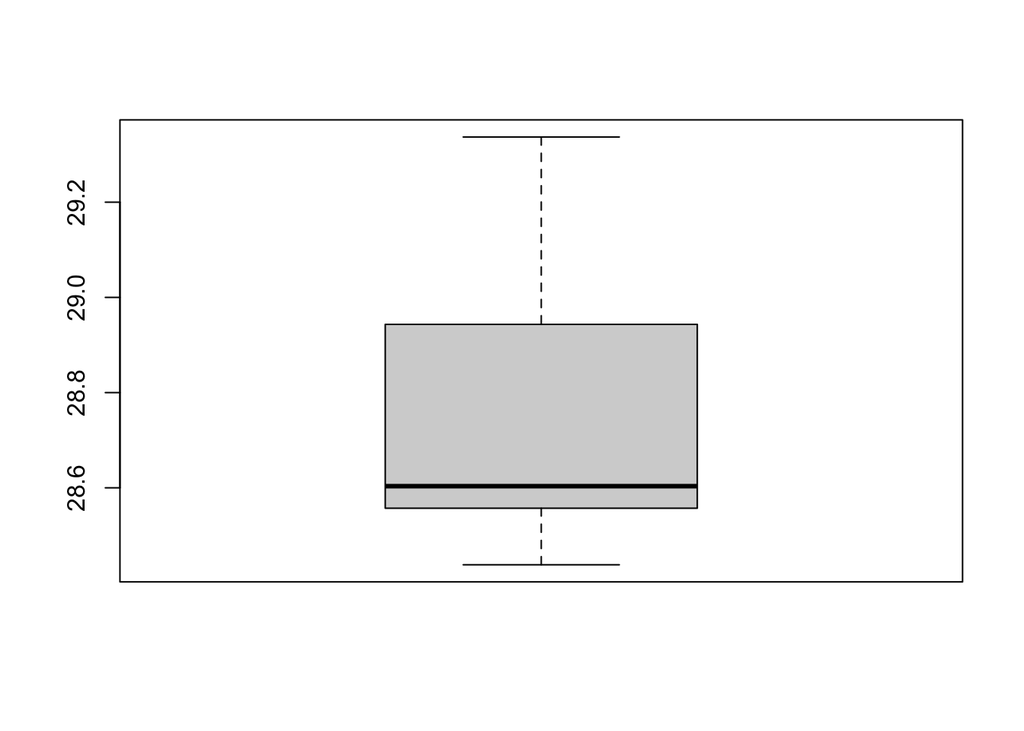

```r
boxplot(latitude)
```

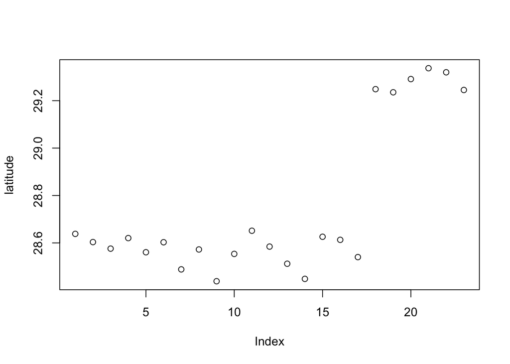

```r
plot(latitude)
```

```r
longitude <- hi[369:391]

print("plots of longitude")
```

```
## [1] "plots of longitude"
```

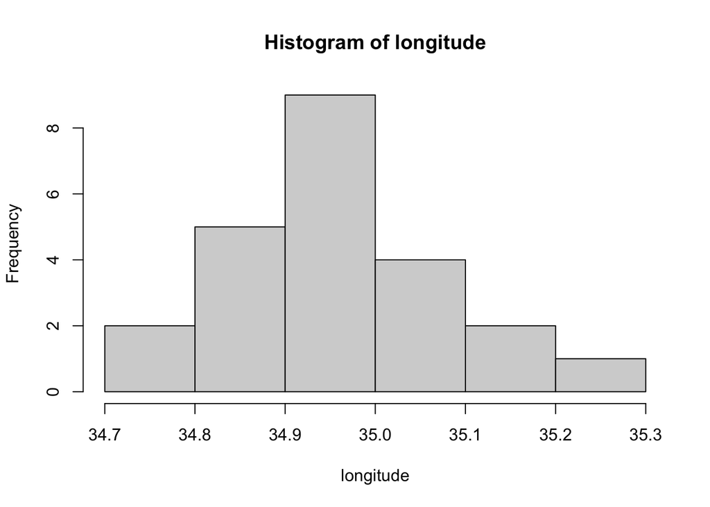

```r
hist(longitude)
```

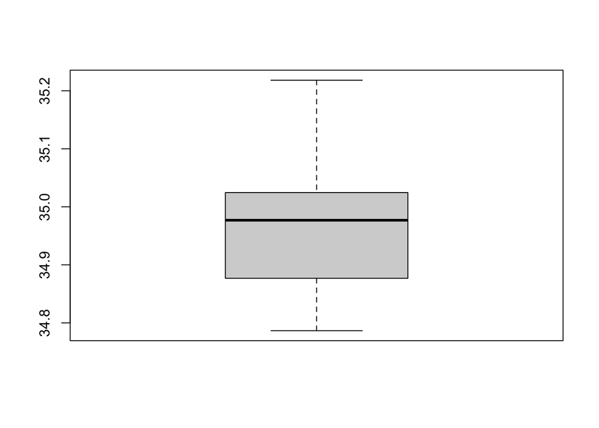

```r
boxplot(longitude)
```

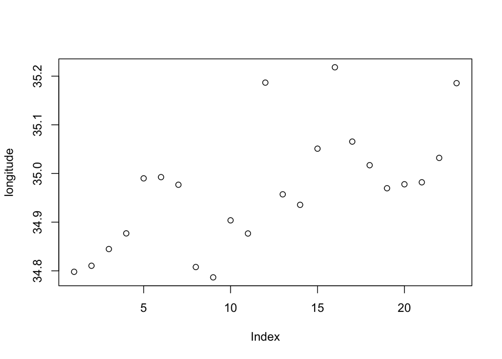

```r
plot(longitude)
```

```r
altitude <- hi[392:414]

print("plots of altitude")
```

```
## [1] "plots of altitude"
```

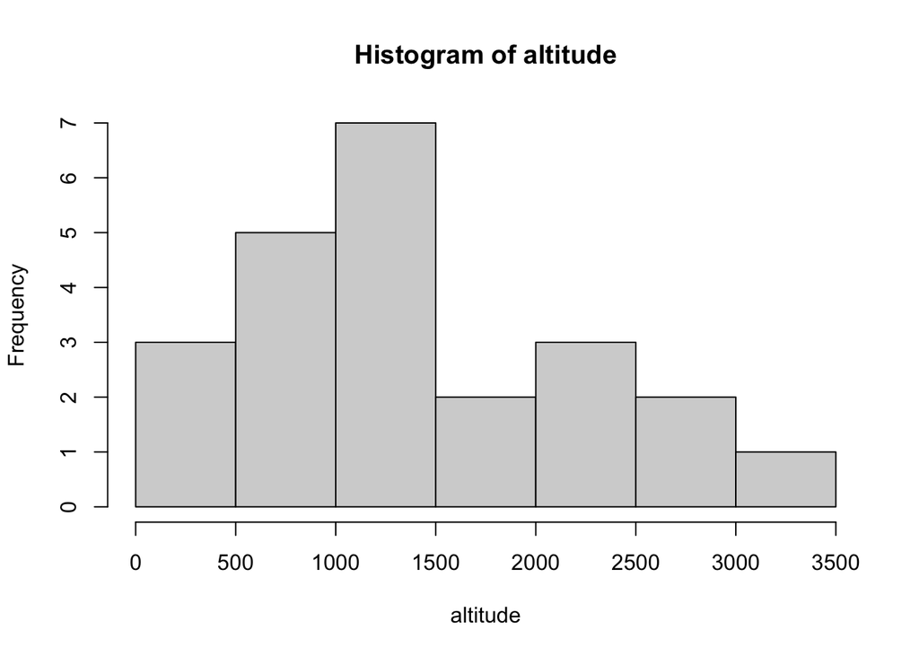

```r
hist(altitude)
```

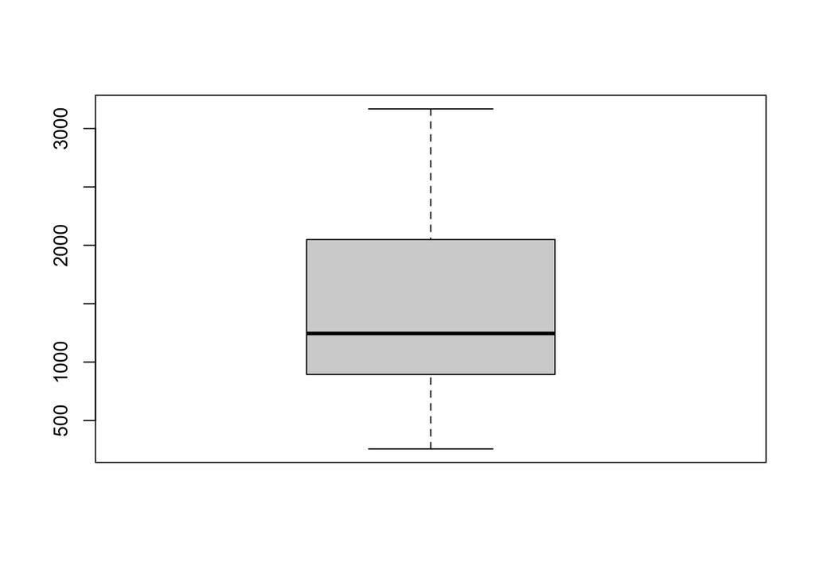

```r
boxplot(altitude)
```

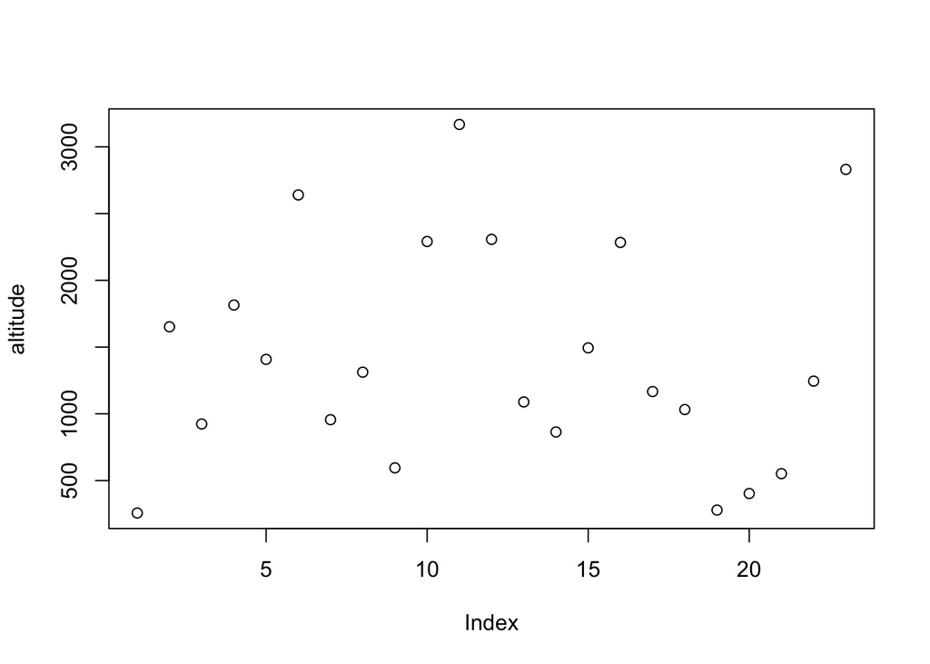

```r
plot(altitude)
```

```r
fault <- hi[415:437]

print("plots of fault")
```

```
## [1] "plots of fault"
```

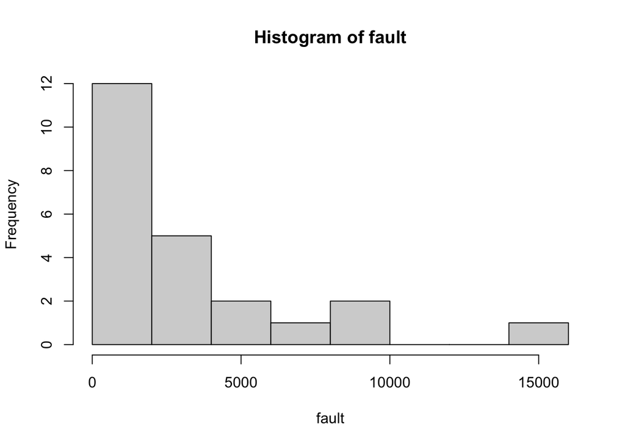

```r
hist(fault)
```

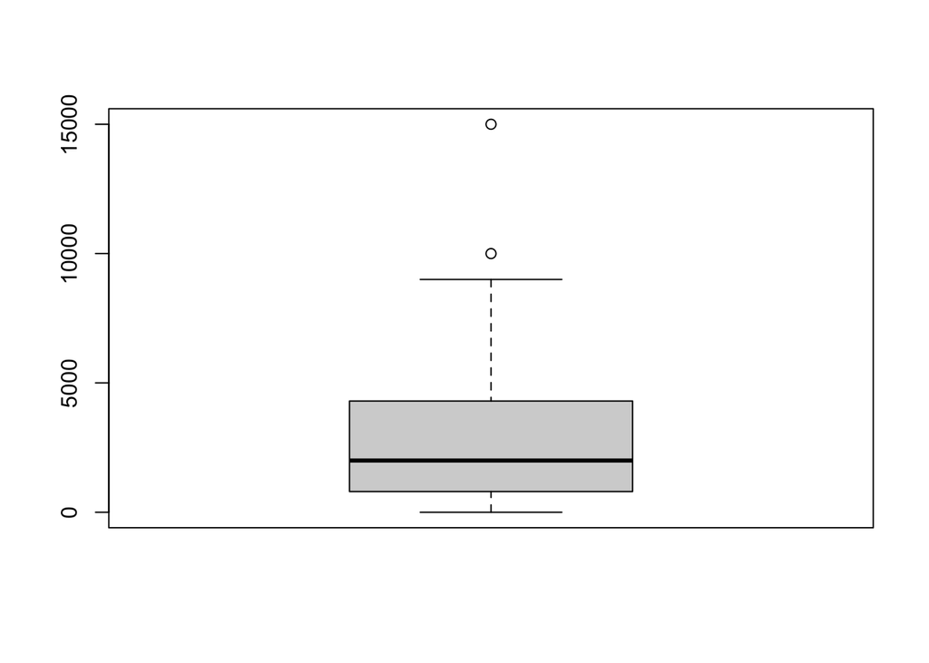

```r
boxplot(fault)
```

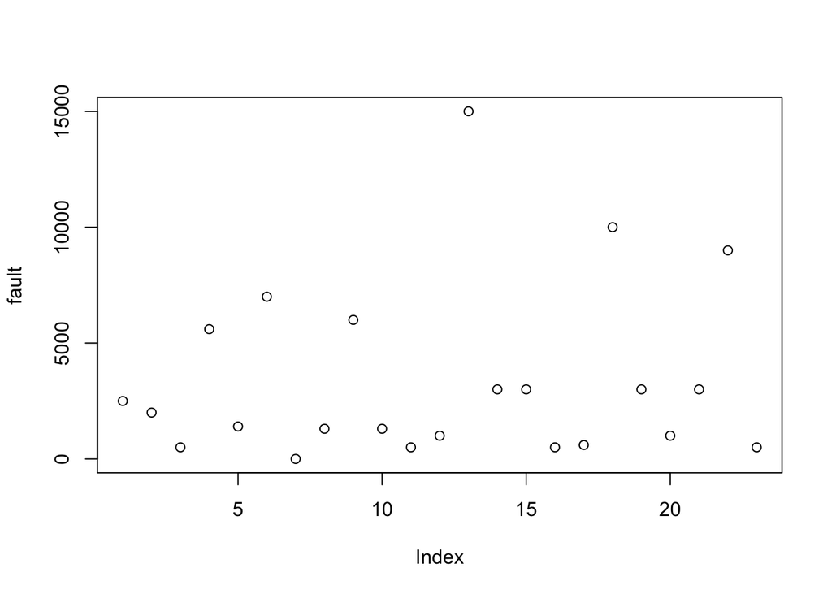

```r
plot(fault)
```